# Toronto AirBnB listing Analysis

YOUNG JUN JEONG

18/JULY/2021

## PART 1: Non-spatial descriptive statistics

#### Installing packages

```r
# install.packages("rtools")
# install.packages("tidyverse")
# install.packages("sf")
# install.packages("lwgeom")
# install.packages("mapboxapi")
# install.packages("leaflet")
# install.packages("reshape2")
# install.packages("geojsonio")
```

#### Loading libraries

```r
library("tidyverse")
library("sf")
library("lwgeom")
library("mapboxapi")
library("leaflet")
library("reshape2")
library("geojsonio")
```

#### Importing non-spatial data

```r
listings <- read_csv("toronto-listings.csv")
```

```r
listings$price <- substring(listings$price, 2, nchar(listings$price)-3) # 1
listings$price <- as.numeric(listings$price) # 2

listings <- listings %>% # 3
  mutate(bathrooms = as.numeric(str_split_fixed(listings$bathrooms_text, " b", 2)[,1])) %>% # 4
  filter(!is.na(room_type) & room_type == "Entire home/apt") # 5
```

1. Changed data in price column to have only integer part by substring function
2. Changed listings$price from character type to numemric type
3. Piping and applying the following functions to listings list
4. Created bathroom column which has character before ’ b’ in numeric type
5. Retrieve only columns that room_type is not NA or equals to ‘Entire home/apt’

```r
neighbourhood_cleansed_df <- listings %>%
  group_by(neighbourhood_cleansed) %>%
  summarise(neighbourhood_cleansed_n = n()) %>%
  filter(neighbourhood_cleansed_n == max(neighbourhood_cleansed_n))

name_neighbourhood_cleansed <- as.character(neighbourhood_cleansed_df[,1])
count_neighbourhood_cleansed <- as.numeric(neighbourhood_cleansed_df[,2])
```

The most frequent neighbourhood where Airbnbs are located is **Waterfront Communities-The Island** with **2422** Airbnbs.

[output not shown]

The mean and the median total cost of Airbnbs in Toronto with the following criteria: 1. Minimum number of nights is equal to or less than 3 2. Number of bathrooms is equal to two or more

```r
mean_med_total_cost <- listings %>%
  filter(minimum_nights <= 3 & bathrooms >= 2) %>%
  summarise(mean_total_cost= mean(total_cost),
            median_total_cost = median(total_cost)) %>%
  round(digits = 1)
mean_total_cost <- as.numeric(mean_med_total_cost[,1])
median_total_cost <- as.numeric(mean_med_total_cost[,2])
```

The average cost of an Airbnb in Toronto with a minimum of 3 or fewer nights is **482.1** and the median cost is **387**. Also, the distribution of total cost of an Airbnb in Toronto is right-skewed since mean is larger than median. ————————————————————————

```r
iqr_total_cost <- listings %>%
  filter(minimum_nights == 1) %>%
  summarise(q1_total_cost = quantile(total_cost, 0.25),
            q3_total_cost = quantile(total_cost, 0.75)) %>%
  mutate(iqr_total_cost = q3_total_cost - q1_total_cost)
```

The interquartile range of total cost for one-night minimum Airbnbs in Toronto is **86 to 170.25**.

A boxplot of the total cost of Airbnbs that require minimum of 1 night only.

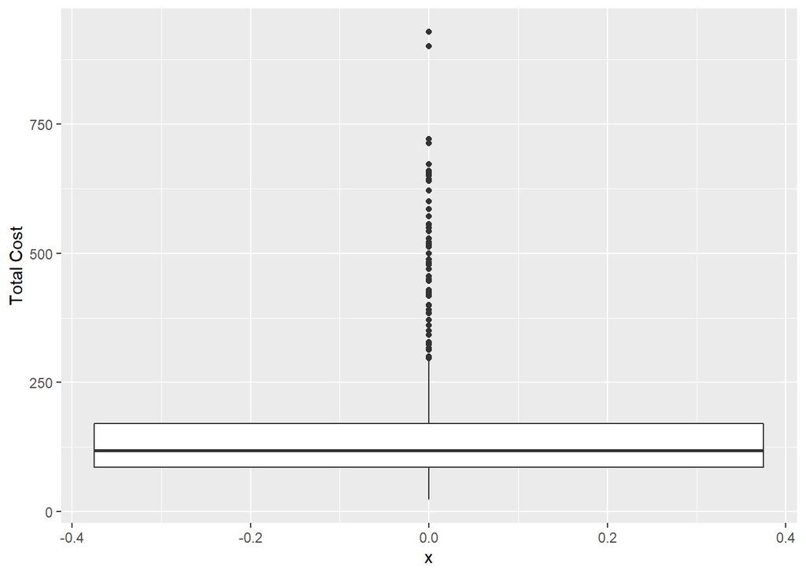

```r
listings %>%
  filter(minimum_nights == 1) %>%
  ggplot(aes(x = 0, y = total_cost)) +
  geom_boxplot() +
  ylab('Total Cost')
```

The IQR is defined as the range of middle-half (50%) of the total cost data is **84.25**. The boxplot tells that the data is extremely right-skewed.

## PART 2: Spatial descriptive statistics

#### Importing data

```r
# IMPORT AND CONVERT DATA
ls <- st_as_sf(listings, coords = c("longitude", "latitude"), crs = 4326) # Toronto Airbnb listings, ls = listings spatial
ls <- st_transform(ls, crs = 32617)

nbs <- st_read("toronto-neighbourhoods.geojson", crs = 4326) # Toronto neighbourhoods, nb = neighbourhoods
```

```r
nbs <- st_transform(nbs, crs = 32617)
nbs_sp <- geojson_read("toronto-neighbourhoods.geojson", what = "sp") # Used for mapping

poi <- st_read("Places-of-Interest-and-Attractions.geojson") # Points of Interest in Toronto, poi = Points of Interest
poi_m <- st_transform(poi, crs = 32617) # poi_m = Points of Interest in meters

# CREATE LAT/LON COLUMNS
ls$coords <- as.character(ls$geometry)
ls$coords <- substring(ls$coords, 3, nchar(ls$coords)-1)
ls <- ls %>%
  mutate(longitude_m = as.numeric(str_split_fixed(ls$coords, ", ", 2)[,1]),
         latitude_m = as.numeric(str_split_fixed(ls$coords, ", ", 2)[,2]))

poi$coords <- as.character(poi$geometry)
poi$coords <- substring(poi$coords, 3, nchar(poi$coords)-1)
poi <- poi %>%
  mutate(longitude = as.numeric(str_split_fixed(poi$coords, ", ", 2)[,1]),
         latitude = as.numeric(str_split_fixed(poi$coords, ", ", 2)[,2]))

poi_m$coords <- as.character(poi_m$geometry)
poi_m$coords <- substring(poi_m$coords, 3, nchar(poi_m$coords)-1)
poi_m <- poi_m %>%
  mutate(longitude_m = as.numeric(str_split_fixed(poi_m$coords, ", ", 2)[,1]),
         latitude_m = as.numeric(str_split_fixed(poi_m$coords, ", ", 2)[,2]))


nbs$coords <- as.character(nbs$geometry)
nbs$coords <- substring(nbs$coords, 3, nchar(nbs$coords)-1)
nbs <- nbs %>%
  mutate(longitude = as.numeric(str_split_fixed(nbs$coords, ", ", 2)[,1]),
         latitude = as.numeric(str_split_fixed(nbs$coords, ", ", 2)[,2]))
```

#### Creating example criteria of a customer Creating a new dataframe considering an example criteria of: - 5 customers would like to rent an Airbnb in Toronto for 5 nights - The customers are planning to spend some time in the city and visit Toronto’s museums - No more than $250/night (collectively) - Minimum 2 bathrooms - Airbnb must accommodate 5 or more people.

You and your 4 friends would also like to stay in a neighbourhood that is in the middle of art gallery locations in the city, so you are located centrally.

1. Filter the Points of interest (‘poi’) dataframe to select only Art Galleries (‘Gallery’)
2. Create 3 map icon/markers for the map. Be creative with your icon/marker image, but make sure it is representative and the resulting map is clear.
3. Create the leaflet map with:
- A basemap (your choice)
- An appropriate zoom level
- Map markers
  - Airbnbs
  - Art galleries with a popup with the gallery name
  - Mean centre of art galleries
  - Neighbourhoods with a popup with the neighbourhood name
4. Identify the neighbourhood where the mean centre of art galleries is located.
5. Identify the lowest cost Airbnb within the identified neighbourhood.
6. Write a sentence identifying the following with inline code:
- Cheapest cost Airbnb within neighbourhood
- Cost of the Airbnb for a five-night stay
- A clickable URL link (‘listing_url’) to the Airbnb you will stay

```r
# 1. Filtering the points of interest
poi <- poi %>%
  filter(CATEGORY == 'Gallery')
```

```r
# 2. Creating point markers to map the points

# Airbnbs
customPoint <- makeIcon(
  iconUrl = "https://cdn.discordapp.com/attachments/771483303093600316/864514198809870356/wfwef.png",
  iconWidth = 25, iconHeight = 25,
  iconAnchorX = 12.5, iconAnchorY = 12.5
)

# Art galleries
artgallery_pts <- makeIcon(
  iconUrl = "https://commonculture.org.uk/wp-content/uploads/leaflet-maps-marker-icons/heritage.png",
  iconWidth = 30, iconHeight = 30,
  iconAnchorX = 15, iconAnchorY = 15
)


# Mean centre
mcIcon <- makeIcon(
  iconUrl = "https://cdn.discordapp.com/attachments/711692521566371960/967242819418877952/kisspng-google-maps-pin-bing-maps-mapquest-how-to-create-a-nice-map-pin-icon-in-photoshop-i-5b630ecb57b8e5.8437748615332185073593-removebg-preview.png",
  iconWidth = 40, iconHeight = 40,
  iconAnchorX = 20, iconAnchorY = 20
)
```

```r
# 3. Creating the leaflet map
leaflet() %>%

  # Adding map layer, basemaps http://leaflet-extras.github.io/leaflet-providers/preview/index.html
  addProviderTiles(providers$CartoDB.DarkMatter) %>%

  # Setting 1st view point (Map centre and zoom level)
  setView(lng = mean(criteria_ls$longitude),
          lat = mean(criteria_ls$latitude),
          zoom = 11.7) %>%

  # Airbnbs
  addMarkers(lng = criteria_ls$longitude,
             lat = criteria_ls$latitude,
             icon = customPoint,
             popup = paste(sep="<br/>",
                           paste(criteria_ls$name),
                           paste('Total cost: $',
                                 paste('<b>',criteria_ls$total_cost,'</b>')))) %>%


  # Art galleries
  addMarkers(lng = poi$longitude,
             lat = poi$latitude,
             icon = artgallery_pts,
             popup = paste(poi$NAME)) %>%

  # Mean centre
  addMarkers(lng = mean(poi$longitude),
             lat = mean(poi$latitude),
             icon = mcIcon,
             popup = paste('Mean Center')) %>%

  # Adding neighbourhoods

  addPolygons(data = nbs_sp,
              color='aquamarine',
              popup = paste('Neighbourhood:', nbs_sp$neighbourhood))
```

[interactive chart not shown]

```r
# 4. Visualization based on the example criteria
mc_poi_neighbourhood <- 'Bay Street Corridor'


lowest_airbnb <- criteria_ls %>%
  filter(neighbourhood_cleansed == mc_poi_neighbourhood) %>%
  filter(total_cost == min(total_cost)) %>%
  select(name, total_cost, listing_url)

name_lowest_airbnb <- as.character(lowest_airbnb[,1])
cost_lowest_airbnb <- as.numeric(lowest_airbnb[,2])
listing_url <- as.character(lowest_airbnb[,3])
```

The cheapest cost Airbnb is named **Luminous Condo** and it will cost **228** dollars for the 5 night stay and the [Airbnb can be seen here](https://www.airbnb.com/rooms/27458995).

A neighbourhood is not a good method to search for an Airbnb based on the mean centre of art galleries. As the leaflet map example shown above, it was a case that choosing a neighbourhood as a method for searching Airbnb becoming a problem due to Segmentation of Areal Units. The mean center was located very close to the borderline of one or two adjacent neighbourhood areas but realistically the calculation of minimum total cost of Airbnb is done within the absolute boundary of the neighbourhood it locates. ————————————————————————